# Bayesian Logistic Regression Application in Diabetes Probability Prediction

IDC6940 Fall 2025 Capstone Project Presentation

Namita Mishra, Autumn Wilcox (Advisor: Dr. Cohen)

2025-09-28

## Our Question

- Can Bayesian logistic regression provide **more stable** and **transparent** inference than classical MLE for diabetes-related outcomes in **NHANES 2013–2014**?
- **Focus predictors:** BMI category (BMDBMIC), Age (RIDAGEYR), Sex (RIAGENDR), Race/Ethnicity (RIDRETH1)
- **Outcome:** DIQ240 (usual diabetes doctor) — diabetes-related; we may swap to DIQ010 (diagnosis) in the next iteration and keep DIQ240 as a covariate.

## Data Pipeline (Reproducible)

- Source: NHANES 2013–2014
- Files: **BMX_H**, **DEMO_H**, **DIQ_H**
- Preprocessing is in **`R/data_prep.R`**
- Analysis slides load prebuilt data:

```
[1] 9813    9
```

## Variables

- **Predictors/Covariates:** BMDBMIC (BMI category), RIDAGEYR (Age), RIAGENDR (Sex), RIDRETH1 (Race/Ethnicity)
- **Survey Design:** WTMEC2YR (weights), SDMVPSU (PSU), SDMVSTRA (strata)
- **Outcome (current placeholder):** DIQ240 — not a diagnosis; proxy for diabetes care.
- **Plan:** consider DIQ010 as outcome; keep DIQ240 as access/behavior covariate.

## Quick EDA: Age Table

| SEQN | BMDBMIC | RIDAGEYR |
| --- | --- | --- |
| 73557 | NA | 69 |
| 73558 | NA | 54 |
| 73559 | NA | 72 |
| 73560 | Normal weight | 9 |
| 73561 | NA | 73 |
| 73562 | NA | 56 |

## Quick EDA: Age Distribution

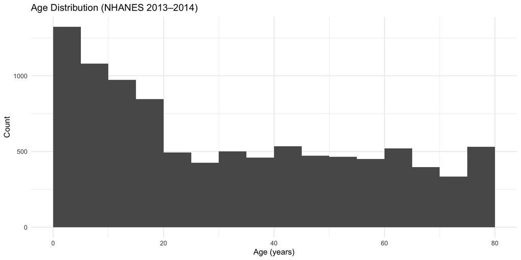

## Quick EDA: BMI Category Codes

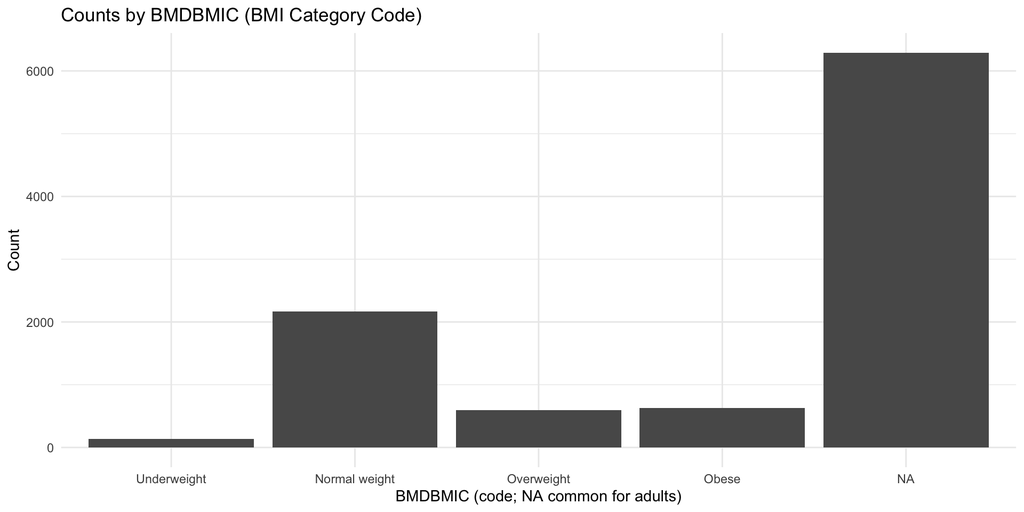

## Survey Design

```
           mean     SE
RIDAGEYR 37.504 0.4412
```

## Methods

- **Baseline:** Logistic regression (MLE)
- **Main:** Bayesian logistic regression with weakly-informative priors
- **Missingness:** Prefer multiple imputation (or Bayesian missing-data modeling) over listwise deletion to avoid instability/separation
- **Compare:** effect estimates (ORs / posteriors), uncertainty (CIs vs credible intervals), calibration and discrimination

## What to Expect in Results

- **Stability:** Priors shrink unstable MLE estimates under separation
- **Uncertainty:** Posteriors provide full credible intervals
- **Practicality:** Survey-aware modeling reflects population inference
- **Sensitivity:** Check priors; compare MI vs. deletion

## Next Steps

- Finalize outcome (DIQ010 likely) and keep DIQ240 as covariate
- Implement MI (document MAR/MNAR assumptions)
- Fit MLE and Bayesian models; add survey-weighted variants
- Report effects, uncertainty, and predictive performance

## References

See references.bib. (Key: survey methods, Bayesian GLMs, imputation.)